# RSPCA report on animal outcomes from our shelters, care and adotion centres

The RSPCA is Australia’s oldest, largest and most trusted animal welfare organisation. With this privileged position comes great responsibility. This year we received[^1] 124,146 animals into our animal shelters and adoption centres across the country.

We are pleased to report that over the past 10 years we have adopted out, reunited with their owners or released back into the wild 718,218 animals. This includes 350,447 dogs/puppies and 283,631 cats/kittens that were adopted or reunited with owners.

With a great deal of effort from RSPCAs all over the country, adoption and reclaiming rates nationally have been increasing over time and significant improvements in the outcomes for cats and dogs (including kittens and puppies) have been achieved. This can be attributed to the introduction of new approaches and programs to increase the number of animals adopted and reunited with their owners. These include highly visible public initiatives, as well as substantial work behind-the-scenes, such as:

- **Extensive promotion of the wonderful animals we have available for adoption** through www.adoptapet.com.au, social media, events and traditional media.
- **Increasing community awareness and support for the value of adopting animals** from shelters and rescue groups more broadly, including through media stories and events.
- **Additional proactive and creative adoption initiatives**, including national events such as Clear the Shelters, promotions around special days and occasions (e.g., Valentine’s Day), promotions focusing on senior animals, promoting adoption of a mother cat and kitten or two kittens together, as well as setting up adoption centres in shopping precincts and pet retail adoption partners such as PetBarn.
- **Working with smaller rescue groups** to extend the reach of adoption initiatives.
- **Providing services to reunite lost pets with their owners.**
- **Providing community and shelter-based desexing schemes** to reduce the number of unplanned pregnancies and unwanted animals, including initiatives reaching pet owners experiencing financial hardship.
- **Expanding foster care networks** to cater for greater numbers of animals. Animals cared for in foster homes may include pregnant animals, those with young litters, orphaned kittens and puppies, seniors, those with special needs, those recovering from surgery, those needing to build their confidence or requiring behavioural training in a home setting, and those that don’t cope well in a shelter environment.
- **Dedicated behavioural trainers** that put in place behavioural modification and management plans for animals requiring specialist support, and who also provide post adoption behavioural classes.
- **Advances in clinical veterinary care** including isolation facilities and improved processes in shelter disease management and surgical rehabilitation.
- **Adoption follow up** with new owners to ensure pets are settling into their new homes and owners are provided with additional information and referral to appropriate telephone or on-site support services.
- **Community information, awareness raising and education** targeting responsible pet ownership and working with local councils, strata committees and landlords to encourage support for pet ownership.
- **Monitoring current research and investment in Australian-based research** to ensure evidence-based approaches to animal welfare.
- **Passionate staff and volunteers** who work tirelessly for the animals in their care.

# 1 All animals

This was a decrease of 8,511 animals or -6.42% from 2017-2018 when we received[^2] 132,657 animals.

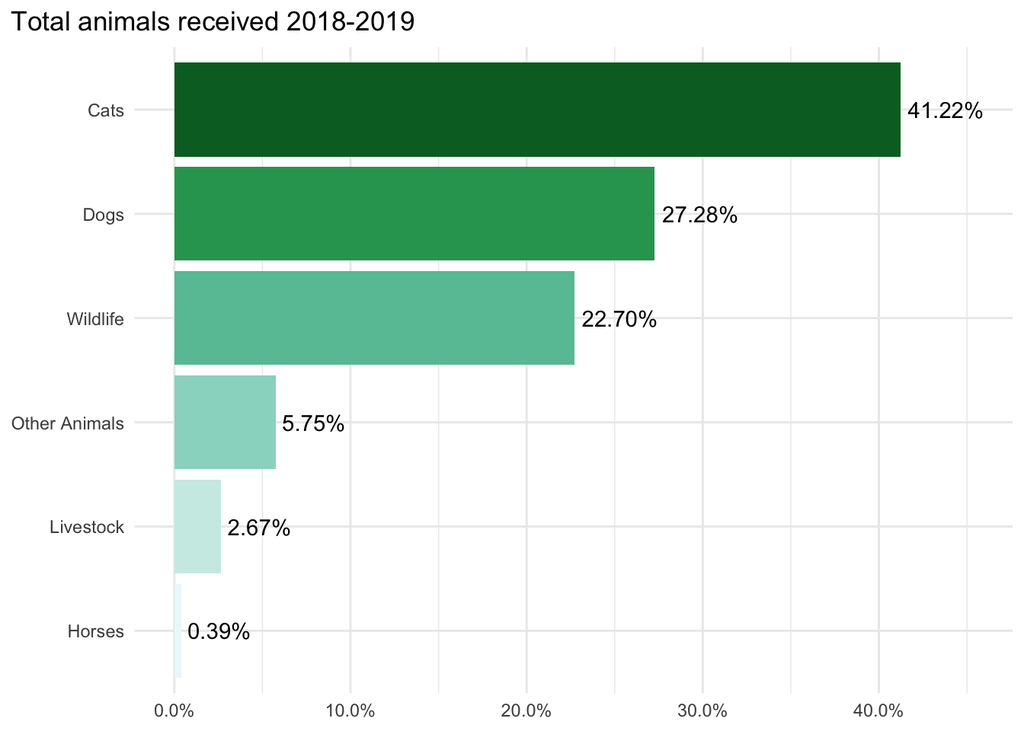

# 2 Dogs

During the 2018-2019 financial year, the RSPCA received[^3] 33,863 dogs with 76.72% of dogs being adopted or reunited with their owners (see figures 2, 3 and 4).

An additional measure for monitoring change over time is what’s called the live release rate (LRR). The 2018-2019 LRR for dogs was 80.83%, which is an increase of 0.58% compared to the previous year. The LRR is the percentage of dogs that were adopted, reclaimed by their owner or transferred to a rescue group or other non-RSPCA facility as a percentage of the total number of dogs received (not including those currently in care or categorised as ‘other’) for the 2018-2019 financial year.

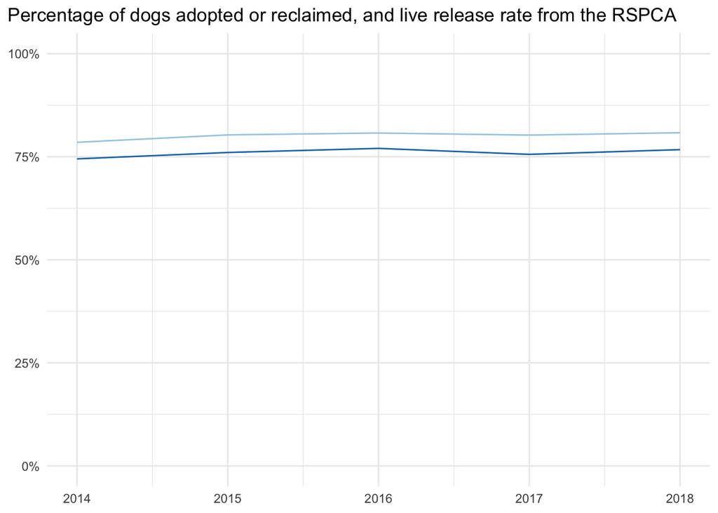

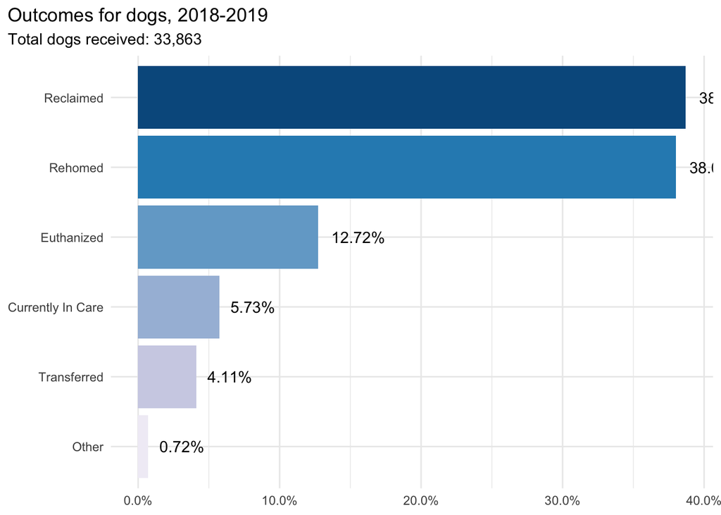

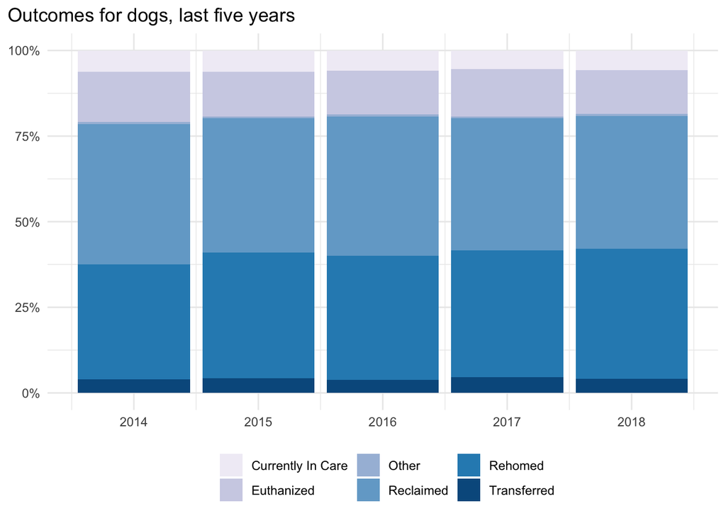

The increased use of microchip identification for dogs supports reuniting lost dogs with their owner. This increase in adoption and reuniting with owners is also the result of our proactive tracing services, care, and rehabilitation activities leading to a decrease in euthanasia.

Sadly, 12.72% (4,308) of dogs/puppies were still humanely euthanased. We remain focused on adopting all animals that are suitable for adoption.

# 3 Cats

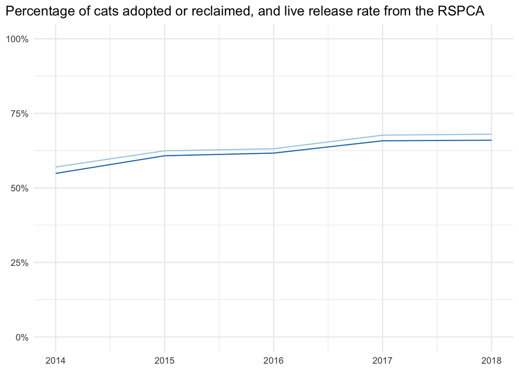

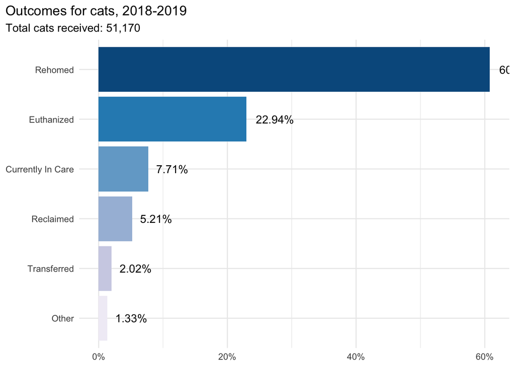

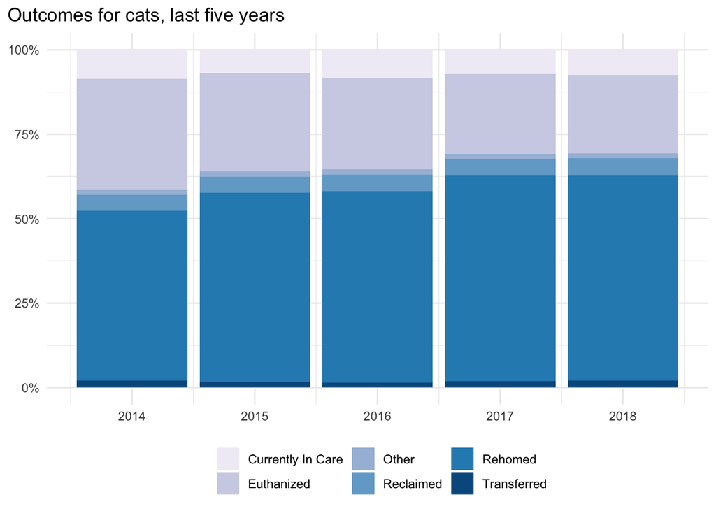

# 4 Wildlife

The number of wildlife presented to the RSPCA has significantly increased in the past decade, since 2008-2009 (11,684 animals in 2008-2009 to 28,183 animals in 2018-2019).

Usually, wildlife (native and introduced) is presented to the RSPCA by members of the community and private veterinary clinics because they have been injured or orphaned. RSPCA QLD particularly operates specialist wildlife clinics and receive, treat, rehabilitate and re-release wildlife.

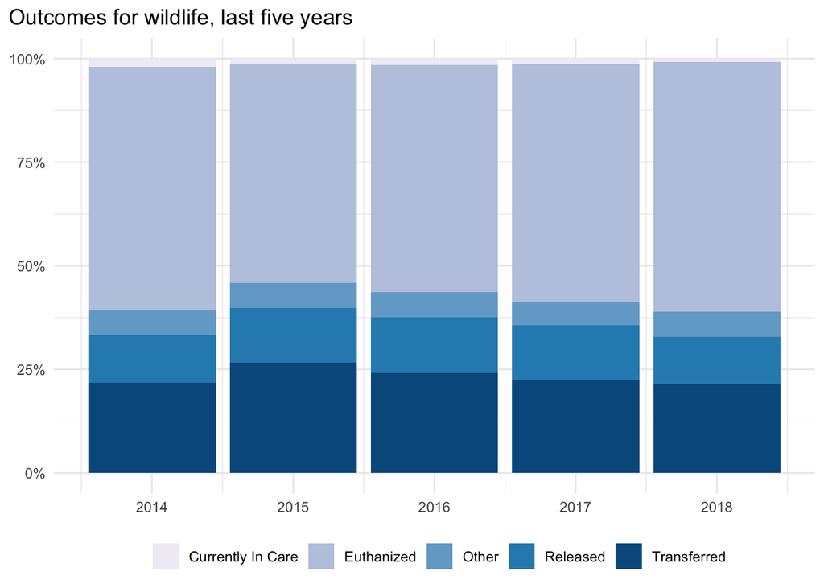

# 5 Trends by state/territory RSPCA

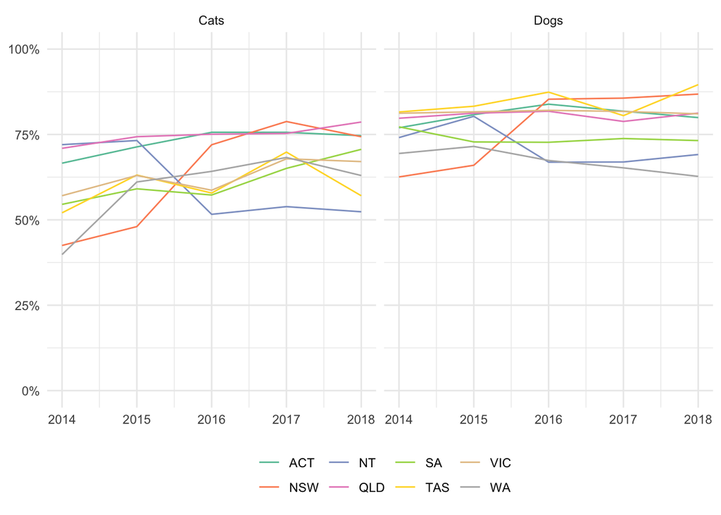

[^1]: Received throughout this report refers to all animals in RSPCA facilities during the 2018-2019 financial year.
[^2]: Note: The total number of animals coming into the care of the RSPCA can be influenced by many factors including the number of local council animal management (pound) contracts the RSPCA might manage in any one year.
[^3]: Received refers to all dogs in RSPCA facilities during the 2018-2019 financial year.